# Research Proposal

How to Plan Your Research

Bogdan G. Popescu

bogdan.popescu@johncabot.edu

John Cabot University

## Background

### Intro

The research proposal is a plan for how you want to do your research.

It should demonstrate that you:

- understand the topic
- have a clear vision for how the project will be completed

## Background

### Background Material

To write the research proposal, you should have covered the following materials:

- The Topic and Research Question
- The Literature Review
- Methods

It also helps to have gone through all the other materials associated with every week.

## Research Proposal

### Structure

**1. Research Question** (~20 words)

- Check out the slides on the Research Question and how it differs from a Research Topic
- Explain the rationale
- Explain the gap

**2. Literature Review and Fit (~600 words)**

- Check out the slides on literature review
- Perform a short literature review (~400 words)
- Explain the rationale and contribution (~200 words)

## Research Proposal

### Structure

**3. Methods** (~100 words)

- Check out the slides on methods
- Clarify here if you are using qualitative, quantitative or mixed methods
- Also explain if you need to collect data
- If you do, what data and how will you analyze it?

## Research Proposal

### Structure

**4. Timeline**

- Explain what paper sections you will complete by what date

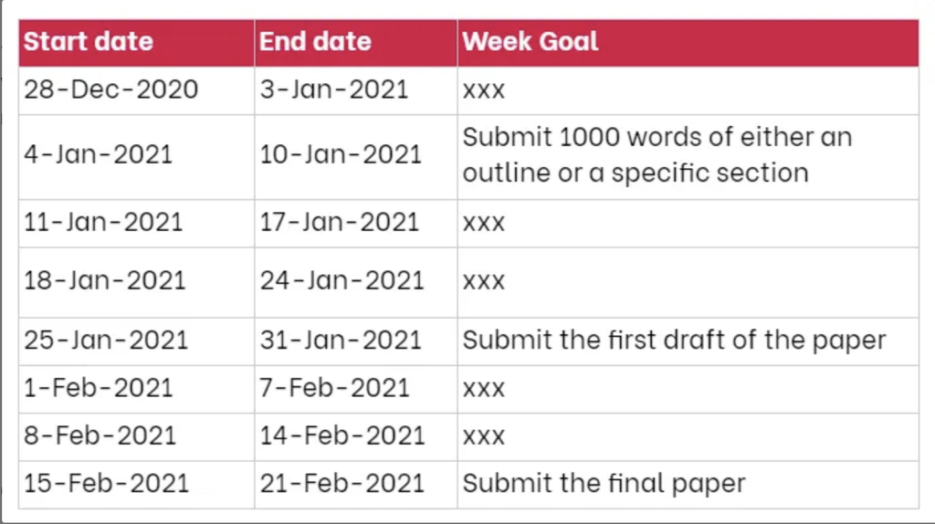

## Research Proposal

### Template

Feel free to use the paper template provided and make changes to the section names and content accordingly.

Please write your research proposal in Quarto and produce two outputs:

- html
- pdf

## Final Note

### Flexibility

The proposal is not set in stone.

Your research question, methodology, and even your literature review may evolve as your research develops.